# Bayesian DEB Modelling of Eisenia fetida Growth and DEBtox Analysis

# 4 Part 2: DEBtox Analysis

## 4.1 Background

The DEBtox framework (Jager et al. 2006; Jager and Zimmer 2012) extends DEB with toxicokinetic-toxicodynamic (TKTD) components. A scaled internal damage variable $D_w$ tracks the toxicant’s effect:

$$\frac{dD_w}{dt} = k_d\bigl(\max(C_w - z_w, 0) - D_w\bigr)$$

where $k_d$ is the damage recovery rate, $C_w$ is the external concentration, and $z_w$ is the **no-effect concentration** (NEC). The damage causes a stress factor $s = b_w \cdot D_w$ that reduces assimilation:

$$\dot{p}_A = f\{p_{Am}\}L^2 \cdot \max(1 - s, \; 0)$$

At steady state ($D_w = C_w - z_w$ for $C_w > z_w$), the EC<sub>50</sub> for 50% assimilation reduction is:

$$\text{EC}_{50} = z_w + \frac{0.5}{b_w}$$

## 4.2 Data exploration

The `debtox_growth` dataset simulates growth under 4 toxicant concentrations (0, 20, 80, 200 arbitrary units), 10 individuals per group, measured weekly over 6 weeks. True parameters: NEC = 15, $b_w = 0.003$.

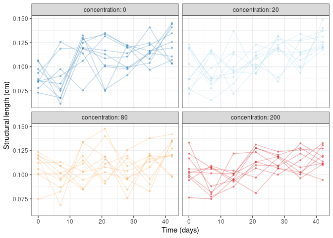

```r
data(debtox_growth)

ggplot(debtox_growth,
       aes(time, length, colour = factor(concentration), group = id)) +
  geom_line(alpha = 0.3) +
  geom_point(size = 0.8, alpha = 0.4) +
  facet_wrap(~concentration, labeller = label_both) +
  theme_bw(base_size = 11) +
  scale_colour_brewer(palette = "RdYlBu", direction = -1) +
  labs(x = "Time (days)", y = "Structural length (cm)",
       colour = "Concentration") +
  theme(legend.position = "none")
```

## 4.3 Data preparation

```r
conc_levels <- unique(debtox_growth$concentration)
conc_map <- setNames(conc_levels, as.character(conc_levels))

dat_tox <- bdeb_data(
  growth        = debtox_growth,
  concentration = conc_map,
  f_food        = 1.0
)
dat_tox
```

```
#>
#> ── BDEB Data ──
#>
#> ℹ Individuals: 40
#> ℹ Endpoints: growth
#> ℹ Functional response (f): 1
#> → Growth: 280 observations, t = [0, 42]
#> → Concentration groups: 4
```

## 4.4 Model specification

```r
mod_tox <- bdeb_tox(dat_tox, stress = "assimilation",
  priors = list(
    p_Am    = prior_lognormal(mu = 1.5, sigma = 0.5),
    p_M     = prior_lognormal(mu = -1.0, sigma = 0.5),
    kappa   = prior_beta(a = 3, b = 2),
    v       = prior_lognormal(mu = -1.5, sigma = 0.5),
    E_G     = prior_lognormal(mu = 6.0, sigma = 0.5),
    sigma_L = prior_halfnormal(sigma = 0.05),
    k_d     = prior_lognormal(mu = -1.0, sigma = 1.0),
    z_w     = prior_lognormal(mu = 2.5, sigma = 1.0),
    b_w     = prior_lognormal(mu = -5.0, sigma = 2.0)
  ))
mod_tox
```

```
#>
#> ── BDEB Model Specification ──
#>
#> ℹ Type: debtox
#> ℹ Stan model: bdeb_debtox
#> ℹ Individuals: 40
#> ℹ Endpoints: growth
#>
#> ── Priors
#> →   p_Am: LogNormal(1.5, 0.5)
#> →   p_M: LogNormal(-1.0, 0.5)
#> →   kappa: Beta(3.0, 2.0)
#> →   v: LogNormal(-1.5, 0.5)
#> →   E_G: LogNormal(6.0, 0.5)
#> →   sigma_L: HalfNormal(0.05)
#> →   k_d: LogNormal(-1.0, 1.0)
#> →   z_w: LogNormal(2.5, 1.0)
#> →   b_w: LogNormal(-5.0, 2.0)
#> →   E0: LogNormal(0.0, 1.0)
#> →   L0: LogNormal(-2.0, 1.0)
#> →   k_R: LogNormal(-1.0, 1.0)
#> →   phi_R: LogNormal(0.0, 1.0)
```

**Prior rationale for toxicological parameters:**

| Parameter | Prior | Median | 95% prior range | Rationale |
| --- | --- | --- | --- | --- |
| $k_d$ | LogNormal(−1, 1) | 0.37 d$^{-1}$ | 0.05–2.7 | Damage recovery: hours to days |
| $z_w$ | LogNormal(2.5, 1) | 12.2 | 1.6–89 | NEC within tested range 0–200 |
| $b_w$ | LogNormal(−5, 2) | 0.0067 | 0.00009–0.5 | Weakly informative on effect intensity |

## 4.5 Fit

For this **demo only**, we fit the DEBtox model with variational inference (ADVI), which yields an approximation of the posterior in seconds rather than minutes. The replication archive uses full HMC (NUTS) with `chains = 4, iter = 1000 + 1000` and is the publication-grade method.

```r
fit_tox <- bdeb_fit(mod_tox, algorithm = "variational",
                    seed = 77, refresh = 0)
```

[output not shown]

## 4.6 Diagnostics

For the variational fit used in this vignette, MCMC-specific diagnostics ($\hat{R}$, divergent transitions, treedepth, ESS) are not defined. In the replication archive, where the same model is fitted with full HMC, `bdeb_diagnose(fit_tox)` and the trace plot below are the appropriate checks.

```r
# Re-fit with algorithm = "sampling" for these diagnostics; see
# the replication archive for the publication-grade analysis.
plot(fit_tox, type = "trace", pars = c("k_d", "z_w", "b_w"))
```

[output not shown]

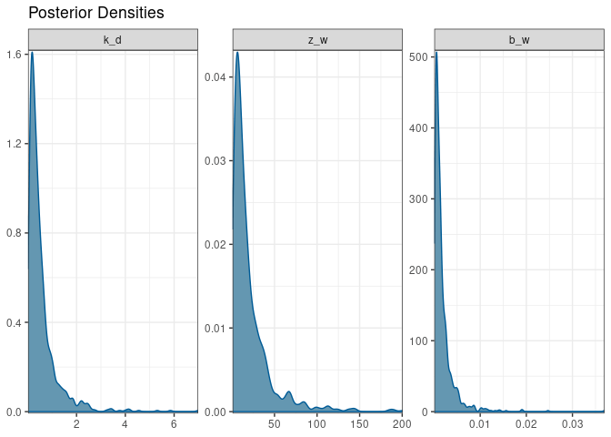

Marginal posterior densities for toxicological parameters.

```r
plot(fit_tox, type = "posterior", pars = c("k_d", "z_w", "b_w"))
```

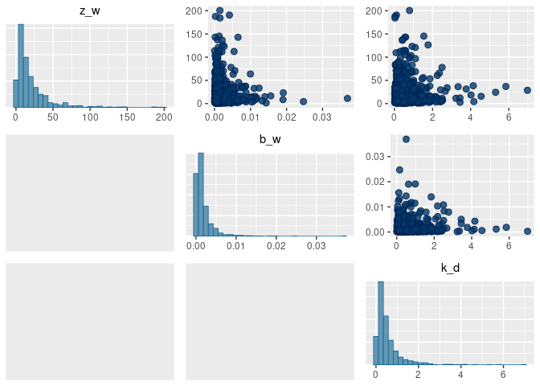

Posterior pairs for toxicological parameters. A correlation between $z_w$ and $b_w$ is expected since both determine the shape of the dose-response curve.

```r
# `bayesplot::mcmc_pairs` requires gridExtra (a Suggests of bayesplot).
plot(fit_tox, type = "pairs", pars = c("z_w", "b_w", "k_d"))
```

## 4.7 Parameter estimates

```r
summary(fit_tox,
  pars = c("p_Am", "p_M", "kappa", "v", "E_G",
           "k_d", "z_w", "b_w", "sigma_L"),
  prob = 0.95)
```

```
#> # A tibble: 9 × 9
#>   variable      mean       sd    median   `2.5%` `97.5%`  rhat ess_bulk ess_tail
#>   <chr>        <dbl>    <dbl>     <dbl>    <dbl>   <dbl> <dbl>    <dbl>    <dbl>
#> 1 p_Am       4.89     1.24      4.74     2.85e+0 7.72e+0 1.00     1096.     975.
#> 2 p_M        0.394    0.181     0.354    1.52e-1 8.53e-1 0.999     882.     938.
#> 3 kappa      0.696    0.0927    0.707    4.99e-1 8.56e-1 1.00      998.    1062.
#> 4 v          0.209    0.0271    0.206    1.60e-1 2.67e-1 0.999     957.     915.
#> 5 E_G      424.      43.2     422.       3.46e+2 5.13e+2 1.000     940.     983.
#> 6 k_d        0.549    0.647     0.354    4.98e-2 2.25e+0 0.999     974.     705.
#> 7 z_w       20.6     24.5      12.5      1.78e+0 8.78e+1 0.999    1006.     906.
#> 8 b_w        0.00181  0.00250   0.00108  1.52e-4 8.02e-3 0.999     968.     981.
#> 9 sigma_L    0.00767  0.00114   0.00754  5.76e-3 1.03e-2 0.999    1084.     875.
```

## 4.8 EC<sub>50</sub> and NEC

The EC<sub>50</sub> is computed analytically in the Stan `generated quantities` block, giving the full posterior distribution without post-hoc root-finding.

```r
ec <- bdeb_ec50(fit_tox, prob = 0.95)
```

```
#>
#> ── DEBtox Effect Concentrations
#>  parameter  mean median    sd lower  upper
#>       EC50 787.2  482.1 930.4 79.59 3296.4
#>        NEC  20.6   12.5  24.5  1.78   87.8
```

```r
print(ec$summary, digits = 3)
```

```
#>       parameter  mean median    sd lower  upper
#> 2.5%       EC50 787.2  482.1 930.4 79.59 3296.4
#> 2.5%1       NEC  20.6   12.5  24.5  1.78   87.8
```

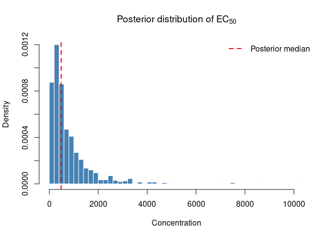

Posterior distribution of EC$_{50}$ (blue histogram) with the posterior median (red dashed line). The full distribution — not just a point estimate — is available for regulatory risk assessment.

```r
hist(ec$draws, breaks = 50, col = "steelblue", border = "white",
     main = expression("Posterior distribution of EC"[50]),
     xlab = "Concentration", freq = FALSE)
abline(v = ec$summary$median[1], col = "red", lwd = 2, lty = 2)
legend("topright", "Posterior median",
       col = "red", lty = 2, lwd = 2, bty = "n")
```

**Interpretation for risk assessment:**

- **NEC ($z_w$):** the concentration threshold below which no toxic effect is expected. A key regulatory endpoint under REACH (ECHA 2017).
- **EC<sub>50</sub>:** the concentration causing 50% reduction in assimilation. The full posterior quantifies the uncertainty: a decision-maker can use, e.g., the lower 5th percentile as a conservative estimate.

## 4.9 Dose-response curve

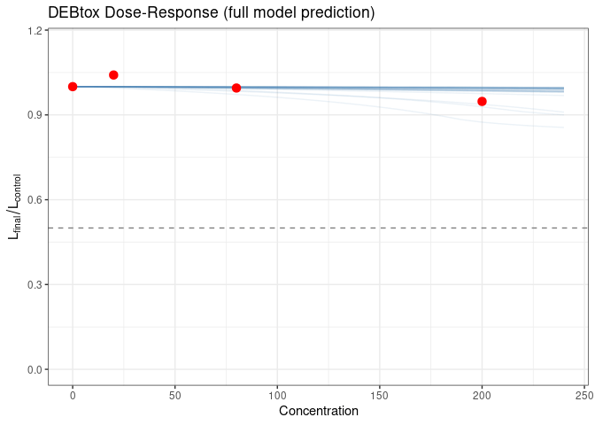

```r
plot_dose_response(fit_tox, n_draws = 30, n_conc = 25)
```

## 4.10 Prior sensitivity analysis

A Bayesian analysis should always report the sensitivity of key conclusions to prior choices. We refit with a tighter prior on $z_w$:

```r
mod_tox2 <- bdeb_tox(dat_tox, stress = "assimilation",
  priors = list(
    z_w = prior_lognormal(mu = 3.0, sigma = 0.3),  # tighter
    b_w = prior_lognormal(mu = -5.0, sigma = 2.0)
  ))
fit_tox2 <- bdeb_fit(mod_tox2, algorithm = "variational",
                     seed = 78, refresh = 0)
```

[output not shown]

```r
cat("=== Original: z_w ~ LogNormal(2.5, 1.0) ===\n")
```

```
#> === Original: z_w ~ LogNormal(2.5, 1.0) ===
```

```r
summary(fit_tox,  pars = c("z_w", "b_w"), prob = 0.95)
```

```
#> # A tibble: 2 × 9
#>   variable     mean       sd   median   `2.5%`  `97.5%`  rhat ess_bulk ess_tail
#>   <chr>       <dbl>    <dbl>    <dbl>    <dbl>    <dbl> <dbl>    <dbl>    <dbl>
#> 1 z_w      20.6     24.5     12.5     1.78     87.8     0.999    1006.     906.
#> 2 b_w       0.00181  0.00250  0.00108 0.000152  0.00802 0.999     968.     981.
```

```r
cat("\n=== Tighter:  z_w ~ LogNormal(3.0, 0.3) ===\n")
```

```
#>
#> === Tighter:  z_w ~ LogNormal(3.0, 0.3) ===
```

```r
summary(fit_tox2, pars = c("z_w", "b_w"), prob = 0.95)
```

```
#> # A tibble: 2 × 9
#>   variable     mean      sd   median    `2.5%`  `97.5%`  rhat ess_bulk ess_tail
#>   <chr>       <dbl>   <dbl>    <dbl>     <dbl>    <dbl> <dbl>    <dbl>    <dbl>
#> 1 z_w      20.8     6.67    20.0     10.5      36.6     1.00      934.     873.
#> 2 b_w       0.00168 0.00171  0.00118  0.000187  0.00576 0.999     972.     924.
```

If the posteriors agree despite different priors, the **data are informative** and the inference is robust. If they diverge, the parameter is **prior-dominated** and should be reported as weakly identified.

# 5 Part 3: Practical Tools

## 5.1 Structural vs physical length

BayesianDEB works with **structural length** $L = V^{1/3}$ (cube root of structural volume), not the physical body length $L_w$ that you measure with a ruler. The two are related by the species-specific **shape coefficient** $\delta_M$:

$$L = \delta_M \times L_w$$

| Species | $\delta_M$ | Source |
| --- | --- | --- |
| *Eisenia fetida* | 0.24 | AmP |
| *Folsomia candida* | 0.19 | AmP |
| *Daphnia magna* | 0.37 | AmP |

**Before fitting**, convert your measured lengths:

```r
# Example: measured body lengths in mm for E. fetida
L_physical_mm <- c(12, 18, 25, 30)
delta_M <- 0.24

# Convert to structural length in cm
L_structural_cm <- delta_M * L_physical_mm / 10
L_structural_cm
```

```
#> [1] 0.288 0.432 0.600 0.720
```

```r
# [1] 0.288 0.432 0.600 0.720
```

If you pass physical lengths directly, the estimated DEB parameters will absorb the shape coefficient and will **not** be comparable with AmP values. BayesianDEB warns if maximum length exceeds 10 cm, which is unusually large for structural length.

## 5.2 Prior predictive check

Before fitting, it is good practice to verify that priors produce biologically plausible predictions (Gabry et al., 2019). Sample directly from the prior distributions and compute derived quantities:

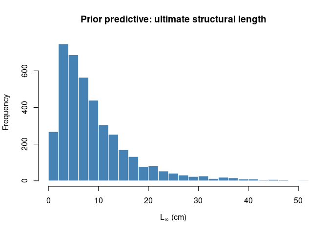

```r
set.seed(42)
n_sim <- 4000

# Sample from priors
p_Am_sim  <- rlnorm(n_sim, 1.5, 0.5)
p_M_sim   <- rlnorm(n_sim, -1.0, 0.5)
kappa_sim <- rbeta(n_sim, 3, 2)
v_sim     <- rlnorm(n_sim, -1.5, 0.5)
E_G_sim   <- rlnorm(n_sim, 6.0, 0.5)

# Prior predictive for L_inf
L_inf_prior <- kappa_sim * p_Am_sim / p_M_sim

hist(L_inf_prior, breaks = 50, col = "steelblue", border = "white",
     main = "Prior predictive: ultimate structural length",
     xlab = expression(L[infinity] ~ "(cm)"), xlim = c(0, 50))
```

```r
# Should cover plausible range for earthworms (~2-20 cm structural)
```

If the prior predictive distribution covers unreasonable values (e.g., $L_\infty > 100$ cm for an earthworm), tighten the priors.

## 5.3 Observation model selection

By default, growth observations use a Gaussian likelihood and reproduction uses negative binomial. You can switch the observation model via the `observation` argument — the Stan likelihood is controlled by integer flags, so **no recompilation is needed**:

```r
# Robust to outliers: Student-t with 5 df
mod_robust <- bdeb_model(dat1, type = "individual",
  observation = list(growth = obs_student_t(nu = 5)))

# Multiplicative error (constant CV)
mod_logn <- bdeb_model(dat1, type = "individual",
  observation = list(growth = obs_lognormal()))
```

```r
# For reproduction with Poisson likelihood (when overdispersion is
# negligible) -- requires growth + reproduction data:
# mod_pois <- bdeb_model(dat_gr, type = "growth_repro",
#   observation = list(growth      = obs_normal(),
#                      reproduction = obs_poisson()))
```

Available observation families:

| Endpoint | Family | Function | When to use |
| --- | --- | --- | --- |
| Growth | Gaussian | `obs_normal()` | Default; additive error |
| Growth | Log-normal | `obs_lognormal()` | Multiplicative error (constant CV) |
| Growth | Student-t | `obs_student_t(nu)` | Outlier-robust |
| Reproduction | Neg. binomial | `obs_negbinom()` | Default; overdispersed counts |
| Reproduction | Poisson | `obs_poisson()` | Equidispersed counts |

## 5.4 Temperature correction

DEB rate parameters scale with temperature via the Arrhenius relationship (Kooijman 2010, Eq. 1.2):

$$c_T = \exp\!\left(\frac{T_A}{T_\text{ref}} - \frac{T_A}{T}\right)$$

```r
# Experiment at 22 C, reference 20 C, typical T_A for ectotherms
cT <- arrhenius(temp = 273.15 + 22, T_ref = 273.15 + 20, T_A = 8000)
cat("Temperature correction factor:", round(cT, 3), "\n")
```

```
#> Temperature correction factor: 1.203
```

```r
# Rate at reference temperature: p_Am_ref = p_Am_obs / cT
```

## 5.5 Energy flux calculator

Inspect the energetics at a specific state:

```r
fl <- deb_fluxes(E = 10, V = 0.5, f = 1.0,
                 p_Am = 5, p_M = 0.5, kappa = 0.75,
                 v = 0.2, E_G = 400)

cat(sprintf("Assimilation  (p_A): %.3f J/d\n", fl$p_A))
```

```
#> Assimilation  (p_A): 3.150 J/d
```

```r
cat(sprintf("Mobilisation  (p_C): %.3f J/d\n", fl$p_C))
```

```
#> Mobilisation  (p_C): 0.008 J/d
```

```r
cat(sprintf("Maintenance   (p_M): %.3f J/d\n", fl$p_M))
```

```
#> Maintenance   (p_M): 0.250 J/d
```

```r
cat(sprintf("Growth        (p_G): %.3f J/d\n", fl$p_G))
```

```
#> Growth        (p_G): 0.000 J/d
```

```r
cat(sprintf("Struct. length (L) : %.3f cm\n",  fl$L))
```

```
#> Struct. length (L) : 0.794 cm
```

```r
cat(sprintf("Scaled reserve (e) : %.3f\n",     fl$e))
```

```
#> Scaled reserve (e) : 0.800
```

## 5.6 Converting cumulative reproduction data

Many protocols report cumulative offspring. The `repro_to_intervals()` function converts these to the interval format required by BayesianDEB:

```r
cumul <- data.frame(
  id = rep(1, 5),
  time = c(0, 7, 14, 21, 28),
  cumulative = c(0, 10, 30, 60, 100)
)
repro_to_intervals(cumul)
```

```
#>     id t_start t_end count
#> 1.1  1       0     7    10
#> 1.2  1       7    14    20
#> 1.3  1      14    21    30
#> 1.4  1      21    28    40
```

```r
#   id t_start t_end count
# 1  1       0     7    10
# 2  1       7    14    20
# 3  1      14    21    30
# 4  1      21    28    40
```

# 6 Validation Against Published DEB Parameters

The `eisenia_growth` dataset was simulated using DEB parameters from the Add-my-Pet (AmP) collection entry for *Eisenia fetida* (Marques et al., 2018). The table below compares the simulation truth with published AmP estimates and the expected posterior recovery from BayesianDEB:

| Parameter | Symbol | True (simulation) | AmP estimate | Units |
| --- | --- | --- | --- | --- |
| Assimilation rate | $\{p_{Am}\}$ | 5.0 | 3.9–6.2 | J d$^{-1}$ cm$^{-2}$ |
| Maintenance rate | $[p_M]$ | 0.5 | 0.3–0.8 | J d$^{-1}$ cm$^{-3}$ |
| Allocation fraction | $\kappa$ | 0.75 | 0.6–0.85 | — |
| Energy conductance | $v$ | 0.2 | 0.1–0.3 | cm d$^{-1}$ |
| Cost of structure | $[E_G]$ | 400 | 200–600 | J cm$^{-3}$ |
| Max. structural length | $L_m$ | 7.5 | 5–12 | cm |

This is not a substitute for fitting real experimental data, but it demonstrates that:

1. The DEB ODE implementation is correct (simulated data match the expected growth pattern).
2. The Bayesian inference machinery recovers known parameters.
3. The prior specification is compatible with realistic parameter ranges from the AmP database.

For real-data applications, we recommend comparing estimated parameters with the AmP entry for the species of interest as a sanity check.

# 7 Summary

This vignette demonstrated three analysis types:

| Analysis | Model type | Individuals | Key output |
| --- | --- | --- | --- |
| Single growth | `"individual"` | 1 | DEB posteriors, PPC, $L_\infty$ |
| Population growth | `"hierarchical"` | 21 | $\mu/\sigma$ of $\{p_{Am}\}$, shrinkage, prediction for new individual |
| Toxicant effect | `"debtox"` | 40 (4 groups) | EC<sub>50</sub>, NEC with full uncertainty |

**What the Bayesian framework provides:**

1. **Full uncertainty quantification** — every derived quantity ($L_\infty$, EC<sub>50</sub>, NEC) comes as a posterior distribution, not a point estimate.
2. **Prior incorporation** — biological knowledge from the AmP database or regulatory guidelines constrains the estimation.
3. **Hierarchical structure** — partial pooling borrows strength across individuals, improving estimates for data-poor organisms.
4. **Principled model checking** — posterior predictive checks and convergence diagnostics provide clear evidence of model adequacy.
5. **Within-chain parallelism** — `reduce_sum` accelerates hierarchical and DEBtox models on multi-core machines.

# References

Betancourt, M. and Girolami, M. (2015). Hamiltonian Monte Carlo for hierarchical models. In: Upadhyay, S.K. et al. (eds) *Current Trends in Bayesian Methodology with Applications*. CRC Press, pp. 79–101.

Carpenter, B., Gelman, A., Hoffman, M.D. et al. (2017). Stan: A probabilistic programming language. *Journal of Statistical Software*, 76(1), 1–32. doi: 10.18637/jss.v076.i01

ECHA (2017). *Guidance on Information Requirements and Chemical Safety Assessment, Chapter R.10: Characterisation of dose [concentration]- response for environment*. European Chemicals Agency.

Gelman, A. (2006). Prior distributions for variance parameters in hierarchical models. *Bayesian Analysis*, 1(3), 515–534. doi: 10.1214/06-BA117A

Gelman, A. and Hill, J. (2006). *Data Analysis Using Regression and Multilevel/Hierarchical Models*. Cambridge University Press.

Gelman, A., Carlin, J.B., Stern, H.S. et al. (2013). *Bayesian Data Analysis*. 3rd edition. Chapman & Hall/CRC.

Hoffman, M.D. and Gelman, A. (2014). The No-U-Turn Sampler: adaptively setting path lengths in Hamiltonian Monte Carlo. *Journal of Machine Learning Research*, 15(47), 1593–1623.

Jager, T., Heugens, E.H.W. and Kooijman, S.A.L.M. (2006). Making sense of ecotoxicological test results: towards application of process-based models. *Ecotoxicology*, 15(3), 305–314. doi: 10.1007/s10646-006-0060-x

Jager, T. and Zimmer, E.I. (2012). Simplified Dynamic Energy Budget model for analysing ecotoxicity data. *Ecological Modelling*, 225, 74–81. doi: 10.1016/j.ecolmodel.2011.11.012

Kooijman, S.A.L.M. (2010). *Dynamic Energy Budget Theory for Metabolic Organisation*. 3rd edition. Cambridge University Press. doi: 10.1017/CBO9780511805400

Marques, G.M., Augustine, S., Lika, K. et al. (2018). The AmP project: comparing species on the basis of dynamic energy budget parameters. *PLOS Computational Biology*, 14(5), e1006100. doi: 10.1371/journal.pcbi.1006100

Vehtari, A., Gelman, A., Simpson, D. et al. (2021). Rank-normalization, folding, and localization: an improved $\hat{R}$ for assessing convergence of MCMC. *Bayesian Analysis*, 16(2), 667–718. doi: 10.1214/20-BA1221